# Statistical evaluation of modified autocidal gravid ovitraps

# Statistical Analysis

Analysis of mosquito trap data for the manuscript “Evaluation of modified autocidal gravid ovitraps for the control of container-breeding mosquitoes in Saint Augustine, FL”

*Adam Rivers*  
*USDA-ARS Genomics and Bioinformatics Unit* *21 December 2020*

# Overview

In this experiment three treatment and control areas were defined in St. Augustine, FL. Mosquito monitoring traps were placed in treatment and control areas at equal densities. In the treatment areas AGO traps were placed to test their effectiveness at reducing mosquito populations. After a 4 week period with no treatment, AGO kill traps were added and each area was monitored for 20 weeks.

[output not shown]

All data are count data of mosquito populations

# Analysis

Load the data frame.

```r
library('tidyverse')
library('lubridate')
library('glmmTMB')

# Load raw data filtering NA's
data <-as_tibble(read.csv("all_trap_data.csv.gz")) %>% filter(!is.na(count)) %>% filter(!is.na(organism))

# break dates into weeks
datetime <- mdy_hm(data$datetime)
data$week <- factor(cut(datetime, breaks="week"),ordered=TRUE)
```

## Analysis of BG trap data

We will first focus on BG traps and female *Aedes aegypti* mosquitoes in BG traps

```r
data_filtered <- filter(data, organism == "aedes_aegypti_female_count" & trap_type =="bg")
```

### Visualize the count data

Data are highly skewed and there appear to be excess zeros. We will use the negative binomial with and without zero inflation.

```r
mean(data_filtered$count)
```

```
## [1] 3.560185
```

```r
sd(data_filtered$count)
```

```
## [1] 6.065848
```

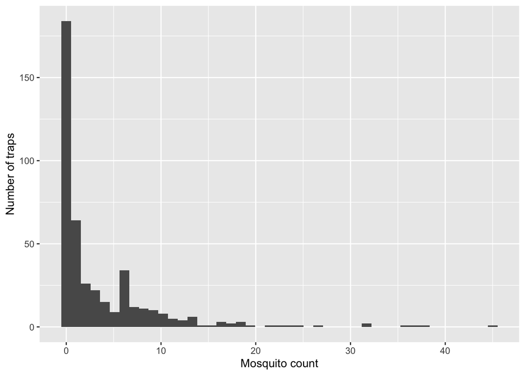

```r
ggplot(data=data_filtered, aes(count)) + geom_histogram(bins=45)+ xlab("Mosquito count") + ylab("Number of traps")
```

```r
ggsave("docs/bg_hist.pdf")
```

### Explore the distribution of female *Aedes aegypti* over time in BG traps

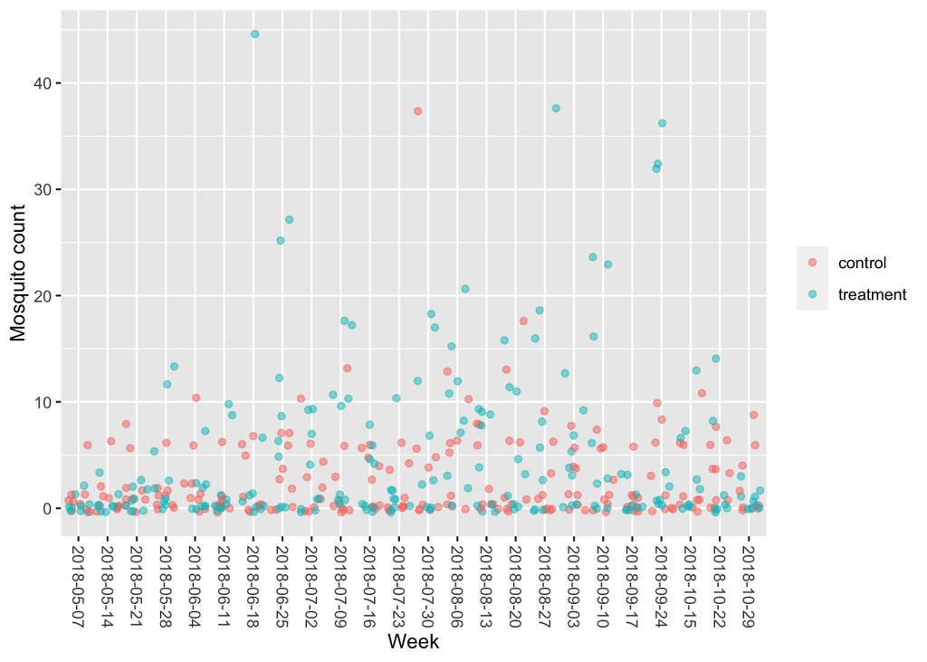

```r
ggplot(aes(x=week, y=count, group=treatment_type, color=treatment_type), data=data_filtered,) +
  geom_jitter(alpha=0.5) +
  theme(axis.text.x=element_text(angle =- 90, vjust = 0.5), legend.title=element_blank()) +
  ylab("Mosquito count") +
  xlab("Week")
```

```r
ggsave("docs/Aedes_aegypti_bg_weekly.pdf")
```

### Model 1

Estimate the number of mosquitoes in a trap as a function of the fixed effect of the treatment (treatment_type) and the random effect of the week.We will evaluate controlling for auto-correlation in time series data by adding auto-correlation structure of order 1 using week.

To use the Zero inflated model we will use the following R package:

Brooks ME, Kristensen K, van Benthem KJ, Magnusson A, Berg CW, Nielsen A, Skaug HJ, Maechler M, Bolker BM (2017). “glmmTMB Balances Speed and Flexibility Among Packages for Zero-inflated Generalized Linear Mixed Modeling.” The R Journal, 9(2), 378–400. https://journal.r-project.org/archive/2017/RJ-2017-066/index.html.

### Model Comparison 1

```r
modela <- glmmTMB(count ~ treatment_type + ar1(week-1|treatment_type), data = data_filtered, family = nbinom2)
modelb <- glmmTMB(count ~ treatment_type + ar1(week-1|treatment_type), data = data_filtered, zi=~factor(treatment_type), family = nbinom2)
modelc <- glmmTMB(count ~ treatment_type + (1|week), data = data_filtered, family = nbinom2)
modeld <- glmmTMB(count ~ treatment_type + (1|week), data = data_filtered, zi=~factor(treatment_type), family = nbinom2)
modele <- glmmTMB(count ~ treatment_type, data = data_filtered, family = nbinom2)
modelf <- glmmTMB(count ~ treatment_type, data = data_filtered, zi=~factor(treatment_type), family = nbinom2)

anova(modela,modelb,modelc,modeld,modele,modelf)
```

|  | Df | AIC | BIC | logLik | deviance | Chisq | Chi Df | Pr(>Chisq) |
| --- | --- | --- | --- | --- | --- | --- | --- | --- |
| modele | 3 | 1930.988 | 1943.193 | -962.4939 | 1924.988 | NA | NA | NA |
| modelc | 4 | 1926.539 | 1942.813 | -959.2696 | 1918.539 | 6.4486126 | 1 | 0.011103902 |
| modela | 5 | 1930.316 | 1950.659 | -960.1582 | 1920.316 | 0.0000000 | 1 | 1.000000000 |
| modelf | 5 | 1929.557 | 1949.899 | -959.7783 | 1919.557 | 0.7598142 | 0 | 0.000000000 |
| modeld | 6 | 1923.586 | 1947.997 | -955.7930 | 1911.586 | 7.9705011 | 1 | 0.004754577 |
| modelb | 7 | 1927.185 | 1955.664 | -956.5927 | 1913.185 | 0.0000000 | 1 | 1.000000000 |

```r
summary(modeld)
```

```
##  Family: nbinom2  ( log )
## Formula:          count ~ treatment_type + (1 | week)
## Zero inflation:         ~factor(treatment_type)
## Data: data_filtered
##
##      AIC      BIC   logLik deviance df.resid
##   1923.6   1948.0   -955.8   1911.6      426
##
## Random effects:
##
## Conditional model:
##  Groups Name        Variance Std.Dev.
##  week   (Intercept) 0.2051   0.4529
## Number of obs: 432, groups:  week, 24
##
## Overdispersion parameter for nbinom2 family (): 0.77
##
## Conditional model:
##                         Estimate Std. Error z value Pr(>|z|)
## (Intercept)               1.1421     0.1638   6.974 3.09e-12 ***
## treatment_typetreatment   0.5162     0.1671   3.089  0.00201 **
## ---
## Signif. codes:  0 '***' 0.001 '**' 0.01 '*' 0.05 '.' 0.1 ' ' 1
##
## Zero-inflation model:
##                                 Estimate Std. Error z value Pr(>|z|)
## (Intercept)                      -1.4080     0.5023  -2.803  0.00506 **
## factor(treatment_type)treatment   0.3795     0.4294   0.884  0.37684
## ---
## Signif. codes:  0 '***' 0.001 '**' 0.01 '*' 0.05 '.' 0.1 ' ' 1
```

```r
library('DHARMa')
```

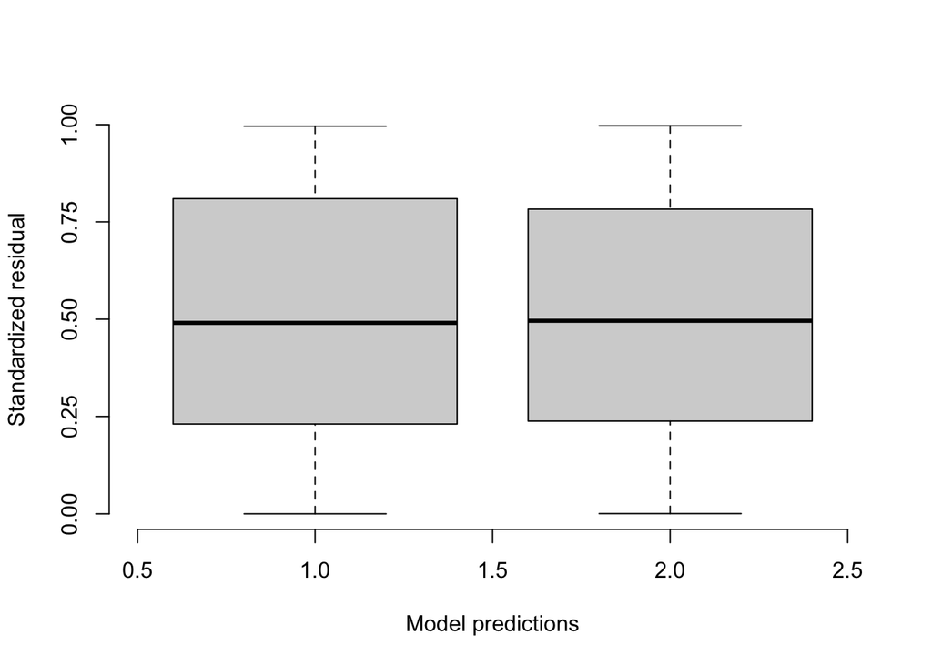

```r
modeld_simres <- simulateResiduals(modeld)
plotResiduals(modeld_simres, quantreg = T)
```

Model 1d is the best supported model. It indicates a non-significant positive association with traps and mosquitoes overall in the ZINB model and a significant positive relation in the conditional model. This suggests the traps were not effective at reducing female *Aedes aegypti*.

### Model 2

```r
model2 <- glmmTMB(count ~ treatment_type*site_pair + (1|week), data = data_filtered, zi=~treatment_type*site_pair, family = nbinom2)
```

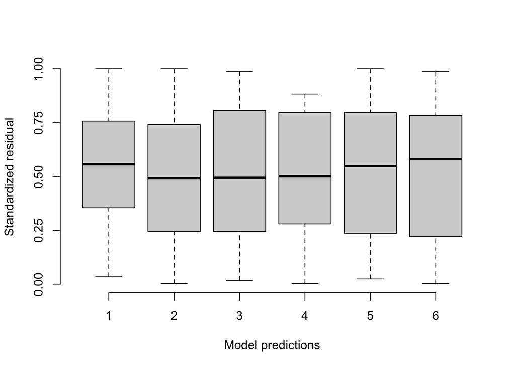

```r
model2_simres <- simulateResiduals(model2)
plotResiduals(model2_simres, quantreg = T)
```

## SAGO trap data

```r
data_filtered2 <- filter(data, organism == "aedes_aegypti_female_count" & trap_type =="sago")
```

### Visualize the count data.

Data are highly skewed and there appear to be many excess zeros. I will evaluate zero inflated methods.

```r
mean(data_filtered2$count)
```

```
## [1] 0.06468531
```

```r
sd(data_filtered2$count)
```

```
## [1] 0.2761478
```

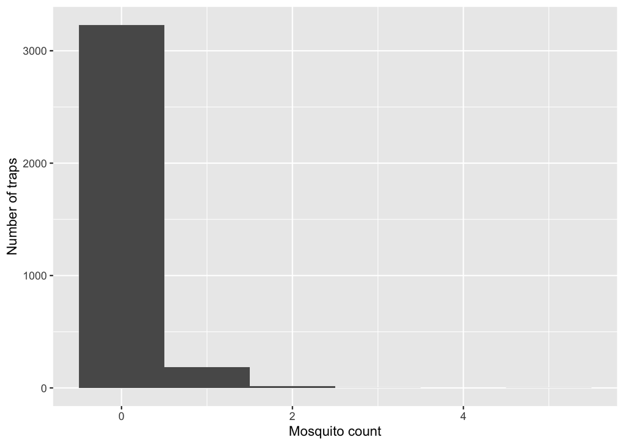

```r
ggplot(data=data_filtered2, aes(count)) + geom_histogram(bins=6)+ xlab("Mosquito count") + ylab("Number of traps")
```

```r
ggsave("docs/sago_hist.pdf")
```

There are many Zeros in the data. A zero inflated Negative Binomial or zero inflated Poisson model may be the most appropriate.

### Explore the distribution of female *Aedes aegypti* over time in SAGO traps

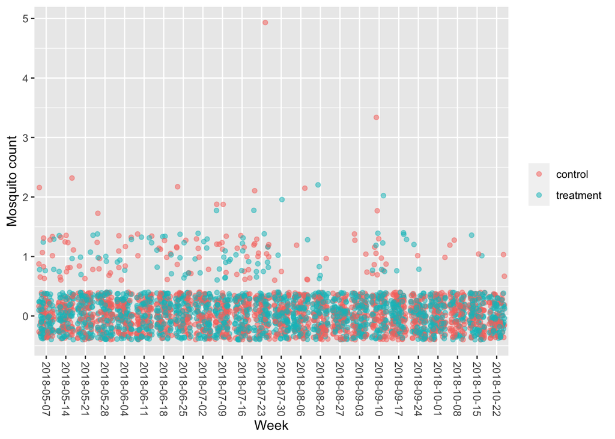

```r
ggplot( aes(x=week, y=count, group=treatment_type, color=treatment_type), data=data_filtered2,) + geom_jitter(alpha=0.5)+ theme(axis.text.x=element_text(angle =- 90, vjust = 0.5), legend.title=element_blank()) + ylab("Mosquito count") + xlab("Week")
```

```r
ggsave("docs/Aedes_aegypti_sago_weekly.pdf")
```

## Zero inflated regression models

To use the Zero inflated model we will use the following R package:

Brooks ME, Kristensen K, van Benthem KJ, Magnusson A, Berg CW, Nielsen A, Skaug HJ, Maechler M, Bolker BM (2017). “glmmTMB Balances Speed and Flexibility Among Packages for Zero-inflated Generalized Linear Mixed Modeling.” The R Journal, 9(2), 378–400. https://journal.r-project.org/archive/2017/RJ-2017-066/index.html.

### Model 3

Glmm’s negative binomial link function.

```r
library(glmmTMB)
model3a <- glmmTMB(count ~ treatment_type, data = data_filtered2, family = nbinom2)
model3b <- glmmTMB(count ~ treatment_type , data = data_filtered2, zi=~treatment_type, family = nbinom2)
model3c <- glmmTMB(count ~ treatment_type + ar1(week-1|treatment_type), data = data_filtered2, family = nbinom2)
model3d <- glmmTMB(count ~ treatment_type + ar1(week-1|treatment_type), data = data_filtered2, zi=~treatment_type, family = nbinom2)
model3e <- glmmTMB(count ~ treatment_type + (1|week), data = data_filtered2, zi=~treatment_type, family = nbinom2)
anova(model3a, model3b, model3c, model3d, model3e)
```

|  | Df | AIC | BIC | logLik | deviance | Chisq | Chi Df | Pr(>Chisq) |
| --- | --- | --- | --- | --- | --- | --- | --- | --- |
| model3a | 3 | 1671.224 | 1689.647 | -832.6121 | 1665.224 | NA | NA | NA |
| model3b | 5 | 1674.527 | 1705.231 | -832.2635 | 1664.527 | 0.6971826 | 2 | 0.705681483 |
| model3c | 5 | 1633.123 | 1663.827 | -811.5614 | 1623.123 | 41.4041010 | 0 | 0.000000000 |
| model3e | 6 | 1625.388 | 1662.233 | -806.6938 | 1613.388 | 9.7351887 | 1 | 0.001807735 |
| model3d | 7 | 1636.785 | 1679.771 | -811.3923 | 1622.785 | 0.0000000 | 1 | 1.000000000 |

Model 3e has the lowest AIC/BIC scores.

```r
summary(model3e)
```

```
##  Family: nbinom2  ( log )
## Formula:          count ~ treatment_type + (1 | week)
## Zero inflation:         ~treatment_type
## Data: data_filtered2
##
##      AIC      BIC   logLik deviance df.resid
##   1625.4   1662.2   -806.7   1613.4     3426
##
## Random effects:
##
## Conditional model:
##  Groups Name        Variance Std.Dev.
##  week   (Intercept) 0.5593   0.7478
## Number of obs: 3432, groups:  week, 24
##
## Overdispersion parameter for nbinom2 family (): 1.22
##
## Conditional model:
##                         Estimate Std. Error z value Pr(>|z|)
## (Intercept)              -2.5649     0.4784  -5.362 8.24e-08 ***
## treatment_typetreatment  -0.6047     0.4627  -1.307    0.191
## ---
## Signif. codes:  0 '***' 0.001 '**' 0.01 '*' 0.05 '.' 0.1 ' ' 1
##
## Zero-inflation model:
##                         Estimate Std. Error z value Pr(>|z|)
## (Intercept)               -1.102      1.759  -0.626    0.531
## treatment_typetreatment  -15.141   3476.414  -0.004    0.997
```

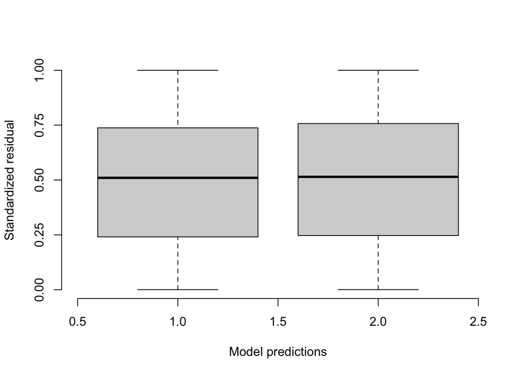

```r
model3e_simres <- simulateResiduals(model3e)
plotResiduals(model3e_simres, quantreg = T)
```

There is not a significant effect of treatment on counts of female *Aedes aegypti* in SAGO traps

# *Aedes albopictus*

## Analysis of BG trap data

We will first focus on BG traps and female *Aedes albopictus* mosquitoes in BG traps

```r
data_filtered3 <- filter(data, organism =="aedes_albopictus_female_count" & trap_type =="bg")
```

### Visualize the count data

Data are highly skewed and there appear to be excess zeros. We will use the negative binomial with and without zero inflation.

```r
mean(data_filtered$count)
```

```
## [1] 3.560185
```

```r
sd(data_filtered$count)
```

```
## [1] 6.065848
```

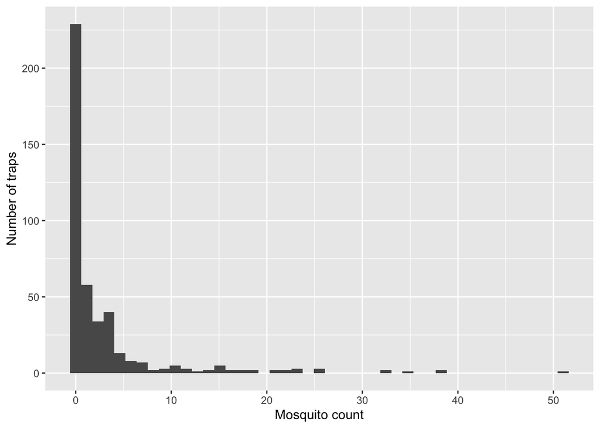

```r
ggplot(data=data_filtered3, aes(count)) + geom_histogram(bins=45)+ xlab("Mosquito count") + ylab("Number of traps")
```

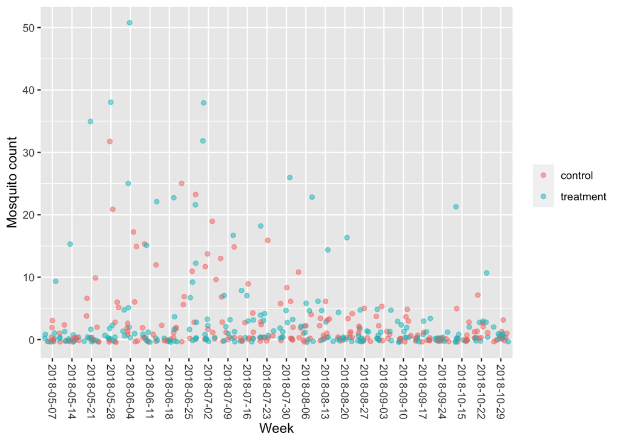

```r
ggsave("docs/bg_albopictus_hist.pdf")
ggplot(aes(x=week, y=count, group=treatment_type, color=treatment_type), data=data_filtered3,) +
  geom_jitter(alpha=0.5) +
  theme(axis.text.x=element_text(angle =- 90, vjust = 0.5), legend.title=element_blank()) +
  ylab("Mosquito count") +
  xlab("Week")
```

```r
ggsave("docs/albopictus_bg_weekly.pdf")
```

## Zero inflated regression Models

To use the Zero inflated model we will use the following R package:

Brooks ME, Kristensen K, van Benthem KJ, Magnusson A, Berg CW, Nielsen A, Skaug HJ, Maechler M, Bolker BM (2017). “glmmTMB Balances Speed and Flexibility Among Packages for Zero-inflated Generalized Linear Mixed Modeling.” The R Journal, 9(2), 378–400. https://journal.r-project.org/archive/2017/RJ-2017-066/index.html.

### Model 4

Glmm’s negative binomial link function.

```r
library(glmmTMB)
model4a <- glmmTMB(count ~ treatment_type, data = data_filtered3, family = nbinom2)
model4b <- glmmTMB(count ~ treatment_type , data = data_filtered3, zi=~treatment_type, family = nbinom2)
model4c <- glmmTMB(count ~ treatment_type + ar1(week-1|treatment_type), data = data_filtered3, family = nbinom2)
model4d <- glmmTMB(count ~ treatment_type + ar1(week-1|treatment_type), data = data_filtered3, zi=~treatment_type, family = nbinom2)
model4e <- glmmTMB(count ~ treatment_type + (1|week), data = data_filtered3, zi=~treatment_type, family = nbinom2)
anova(model4a, model4b, model4c, model4d, model4e)
```

|  | Df | AIC | BIC | logLik | deviance | Chisq | Chi Df | Pr(>Chisq) |
| --- | --- | --- | --- | --- | --- | --- | --- | --- |
| model4a | 3 | 1656.694 | 1668.899 | -825.3470 | 1650.694 | NA | NA | NA |
| model4b | 5 | 1660.678 | 1681.020 | -825.3388 | 1650.678 | 0.01644682 | 2 | 0.9918103 |
| model4c | 5 | 1644.316 | 1664.658 | -817.1581 | 1634.316 | 16.36129944 | 0 | 0.0000000 |
| model4e | 6 | 1643.682 | 1668.093 | -815.8412 | 1631.682 | 2.63386284 | 1 | 0.1046069 |
| model4d | 7 | 1647.691 | 1676.170 | -816.8455 | 1633.691 | 0.00000000 | 1 | 1.0000000 |

```r
summary(model4c)
```

```
##  Family: nbinom2  ( log )
## Formula:          count ~ treatment_type + ar1(week - 1 | treatment_type)
## Data: data_filtered3
##
##      AIC      BIC   logLik deviance df.resid
##   1644.3   1664.7   -817.2   1634.3      427
##
## Random effects:
##
## Conditional model:
##  Groups         Name           Variance Std.Dev. Corr
##  treatment_type week2018-05-07 0.3732   0.6109   0.83 (ar1)
## Number of obs: 432, groups:  treatment_type, 2
##
## Overdispersion parameter for nbinom2 family (): 0.285
##
## Conditional model:
##                         Estimate Std. Error z value Pr(>|z|)
## (Intercept)               0.5571     0.3963   1.406    0.160
## treatment_typetreatment   0.3777     0.5464   0.691    0.489
```

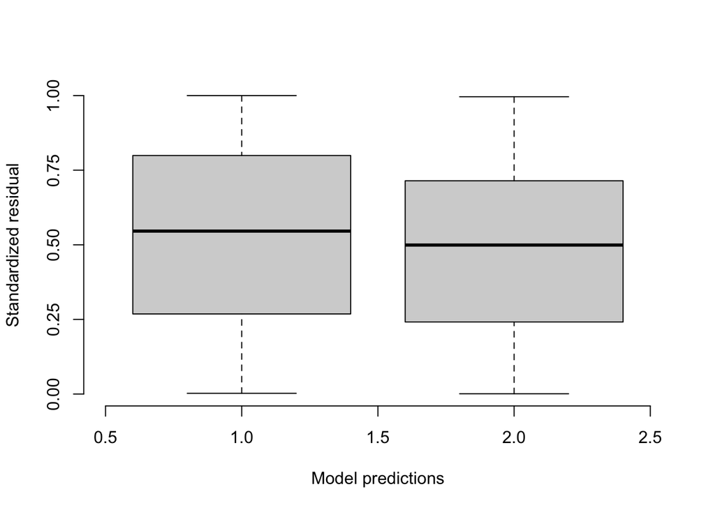

```r
model4c_simres <- simulateResiduals(model4c)
plotResiduals(model4c_simres, quantreg = T)
```

## Analysis of SAGO trap data for female *Aedes albopictus*

Select female *Aedes albopictus* mosquitoes in SAGO traps

```r
data_filtered3b <- filter(data, organism =="aedes_albopictus_female_count" & trap_type =="sago")
```

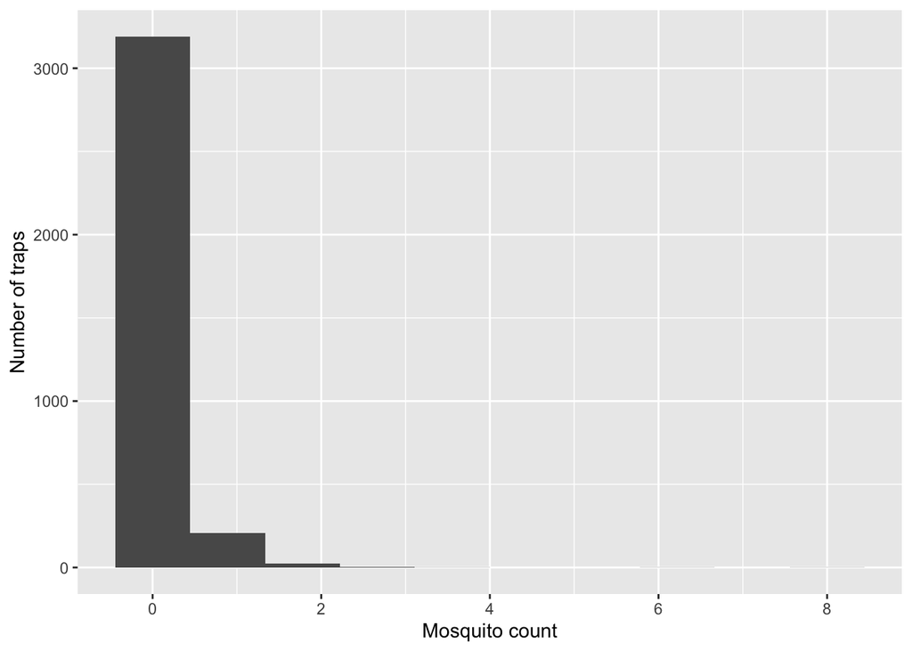

```r
ggplot(data=data_filtered3b, aes(count)) + geom_histogram(bins=10)+ xlab("Mosquito count") + ylab("Number of traps")
```

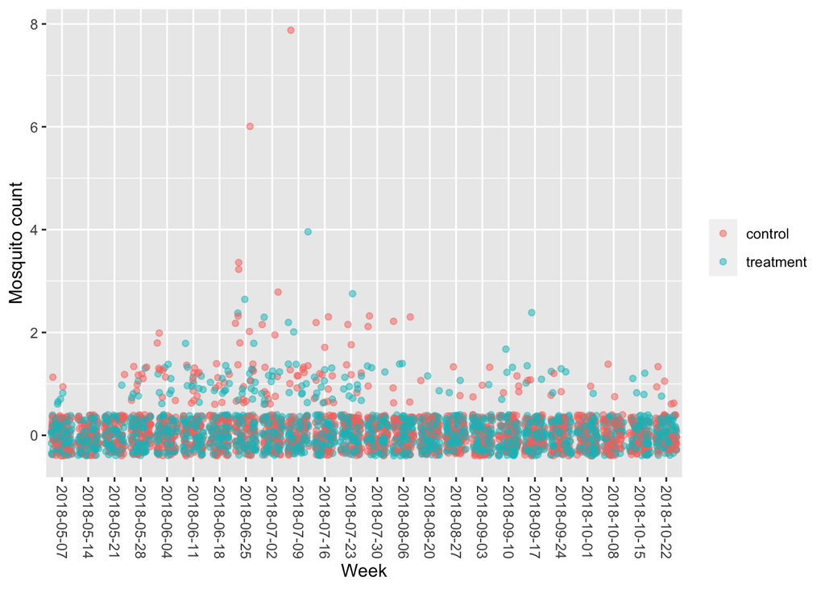

```r
ggsave("docs/albopictus_sago_hist.pdf")
ggplot(aes(x=week, y=count, group=treatment_type, color=treatment_type), data=data_filtered3b,) +
  geom_jitter(alpha=0.5) +
  theme(axis.text.x=element_text(angle =- 90, vjust = 0.5), legend.title=element_blank()) +
  ylab("Mosquito count") +
  xlab("Week")
```

```r
ggsave("docs/albopictus_sago_weekly.pdf")
```

# *All mosquitoes*

## Analysis of BG trap data

We will first focus on BG traps and all mosquitoes in BG traps

```r
data_filtered4 <- filter(data, organism !="non_target_count" & trap_type =="bg")
```

### Visualize the count data

Data are highly skewed and there appear to be excess zeros. We will use the negative binomial with and without zero inflation.

```r
mean(data_filtered$count)
```

```
## [1] 3.560185
```

```r
sd(data_filtered$count)
```

```
## [1] 6.065848
```

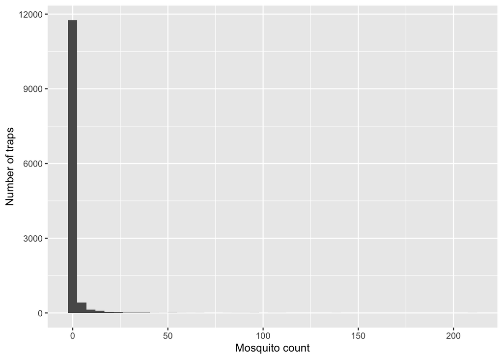

```r
ggplot(data=data_filtered4, aes(count)) + geom_histogram(bins=45)+ xlab("Mosquito count") + ylab("Number of traps")
```

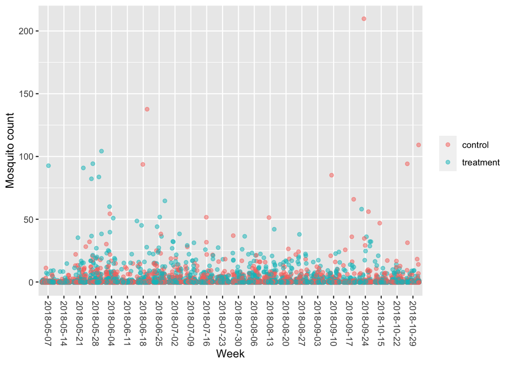

```r
ggsave("docs/bg_hist.pdf")
ggplot(aes(x=week, y=count, group=treatment_type, color=treatment_type), data=data_filtered4,) +
  geom_jitter(alpha=0.5) +
  theme(axis.text.x=element_text(angle =- 90, vjust = 0.5), legend.title=element_blank()) +
  ylab("Mosquito count") +
  xlab("Week")
```

```r
ggsave("docs/all_bg_weekly.pdf")
```

We will first focus on BG traps and female All mosquitoes in BG traps

## Zero inflated regression Models

To use the Zero inflated model we will use the following R package:

Brooks ME, Kristensen K, van Benthem KJ, Magnusson A, Berg CW, Nielsen A, Skaug HJ, Maechler M, Bolker BM (2017). “glmmTMB Balances Speed and Flexibility Among Packages for Zero-inflated Generalized Linear Mixed Modeling.” The R Journal, 9(2), 378–400. https://journal.r-project.org/archive/2017/RJ-2017-066/index.html.

### Model 5

Glmm’s negative binomial link function.

```r
library(glmmTMB)
model5a <- glmmTMB(count ~ treatment_type, data = data_filtered4, family = nbinom2)
model5b <- glmmTMB(count ~ treatment_type , data = data_filtered4, zi=~treatment_type, family = nbinom2)
model5c <- glmmTMB(count ~ treatment_type + ar1(week-1|treatment_type), data = data_filtered4, family = nbinom2)
model5d <- glmmTMB(count ~ treatment_type + ar1(week-1|treatment_type), data = data_filtered4, zi=~treatment_type, family = nbinom2)
model5e <- glmmTMB(count ~ treatment_type + (1|week), data = data_filtered4, zi=~treatment_type, family = nbinom2)
```

```r
anova(model5a, model5b, model5c, model5d, model5e)
```

|  | Df | AIC | BIC | logLik | deviance | Chisq | Chi Df | Pr(>Chisq) |
| --- | --- | --- | --- | --- | --- | --- | --- | --- |
| model5a | 3 | 16095.57 | 16117.87 | -8044.784 | 16089.57 | NA | NA | NA |
| model5b | 5 | 16098.29 | 16135.47 | -8044.143 | 16088.29 | 1.281004 | 2 | 0.527027768 |
| model5c | 5 | 16042.65 | 16079.83 | -8016.327 | 16032.65 | 55.633345 | 0 | 0.000000000 |
| model5e | 6 | 16034.07 | 16078.69 | -8011.036 | 16022.07 | 10.580231 | 1 | 0.001143033 |
| model5d | 7 | 16044.94 | 16096.99 | -8015.470 | 16030.94 | 0.000000 | 1 | 1.000000000 |

Model 5e has the lowest AIC/BIC scores.

```r
summary(model5e)
```

```
##  Family: nbinom2  ( log )
## Formula:          count ~ treatment_type + (1 | week)
## Zero inflation:         ~treatment_type
## Data: data_filtered4
##
##      AIC      BIC   logLik deviance df.resid
##  16034.1  16078.7  -8011.0  16022.1    12522
##
## Random effects:
##
## Conditional model:
##  Groups Name        Variance Std.Dev.
##  week   (Intercept) 0.2756   0.525
## Number of obs: 12528, groups:  week, 24
##
## Overdispersion parameter for nbinom2 family (): 0.0414
##
## Conditional model:
##                         Estimate Std. Error z value Pr(>|z|)
## (Intercept)              -0.4028     0.1418   -2.84  0.00451 **
## treatment_typetreatment   0.1296     0.1147    1.13  0.25854
## ---
## Signif. codes:  0 '***' 0.001 '**' 0.01 '*' 0.05 '.' 0.1 ' ' 1
##
## Zero-inflation model:
##                          Estimate Std. Error z value Pr(>|z|)
## (Intercept)               -2.5662     0.8655  -2.965  0.00303 **
## treatment_typetreatment  -12.2244  1119.6987  -0.011  0.99129
## ---
## Signif. codes:  0 '***' 0.001 '**' 0.01 '*' 0.05 '.' 0.1 ' ' 1
```

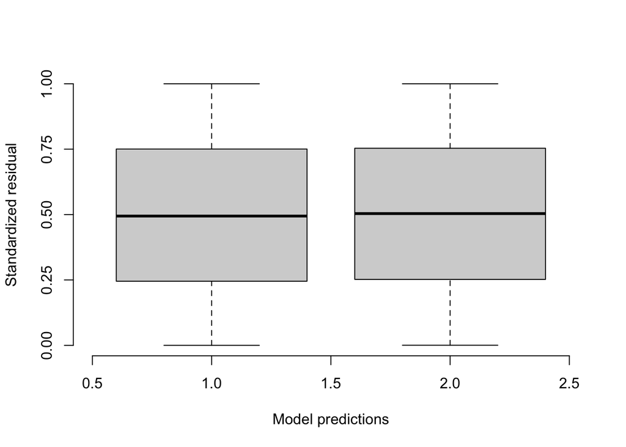

```r
model5e_simres <- simulateResiduals(model5e)
plotResiduals(model5e_simres, quantreg = T)
```

Select female *Aedes albopictus* mosquitoes in SAGO traps

```r
data_filtered4b <- filter(data, organism =="aedes_albopictus_female_count" & trap_type =="sago")
```

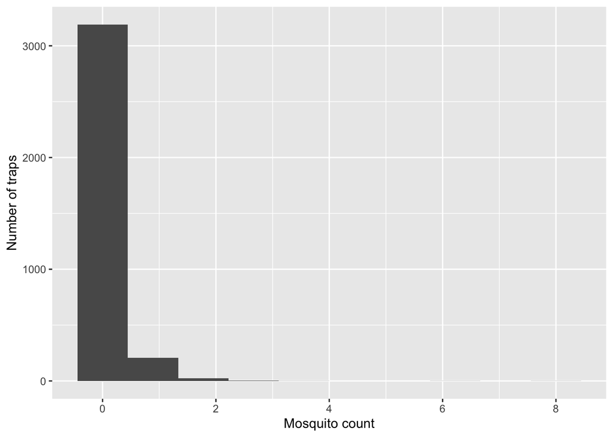

```r
ggplot(data=data_filtered4b, aes(count)) + geom_histogram(bins=10)+ xlab("Mosquito count") + ylab("Number of traps")
```

[output not shown]

[figure not shown]

```r
ggsave("docs/all_mosquitoes_sago_hist.pdf")
```

```r
ggsave("docs/all_mosquitoes_sago_weekly.pdf")
```